# Group_2

This exercise relates to the College data set, which can be found in the  
file College.csv on the book website. It contains a number of  
variables for 777 different universities and colleges in the US.

**The variables are:**

**• Private : Public/private indicator**  
**• Apps : Number of applications received**  
**• Accept : Number of applicants accepted**  
**• Enroll : Number of new students enrolled**  
**• Top10perc : New students from top 10% of high school class**  
**• Top25perc : New students from top 25% of high school class**  
**• F.Undergrad : Number of full-time undergraduates**  
**• P.Undergrad : Number of part-time undergraduates**  
**• Outstate : Out-of-state tuition**  
**• Room.Board : Room and board costs**  
**• Books : Estimated book costs**  
**• Personal : Estimated personal spending**  
**• PhD : Percent of faculty with Ph.D.s**  
**• Terminal : Percent of faculty with terminal degree**  
**• S.F.Ratio : Student/faculty ratio**  
**• perc.alumni : Percent of alumni who donate**  
**• Expend : Instructional expenditure per student**  
**• Grad.Rate : Graduation rate**

Before reading the data into Python, it can be viewed in Excel or a  
text editor.

**(a) Use the pd.read_csv() function to read the data into Python. Call the loaded data college. Make sure that you have the directory set to the correct location for the data.**

```python
import pandas as pd
import seaborn as sns
import matplotlib.pyplot as plt
```

```python
college = pd.read_csv('College.csv')
college.head()
```

|  | Unnamed: 0 | Private | Apps | Accept | Enroll | Top10perc | Top25perc | F.Undergrad | P.Undergrad | Outstate | Room.Board | Books | Personal | PhD | Terminal | S.F.Ratio | perc.alumni | Expend | Grad.Rate |
| --- | --- | --- | --- | --- | --- | --- | --- | --- | --- | --- | --- | --- | --- | --- | --- | --- | --- | --- | --- |
| 0 | Abilene Christian University | Yes | 1660 | 1232 | 721 | 23 | 52 | 2885 | 537 | 7440 | 3300 | 450 | 2200 | 70 | 78 | 18.1 | 12 | 7041 | 60 |
| 1 | Adelphi University | Yes | 2186 | 1924 | 512 | 16 | 29 | 2683 | 1227 | 12280 | 6450 | 750 | 1500 | 29 | 30 | 12.2 | 16 | 10527 | 56 |
| 2 | Adrian College | Yes | 1428 | 1097 | 336 | 22 | 50 | 1036 | 99 | 11250 | 3750 | 400 | 1165 | 53 | 66 | 12.9 | 30 | 8735 | 54 |
| 3 | Agnes Scott College | Yes | 417 | 349 | 137 | 60 | 89 | 510 | 63 | 12960 | 5450 | 450 | 875 | 92 | 97 | 7.7 | 37 | 19016 | 59 |
| 4 | Alaska Pacific University | Yes | 193 | 146 | 55 | 16 | 44 | 249 | 869 | 7560 | 4120 | 800 | 1500 | 76 | 72 | 11.9 | 2 | 10922 | 15 |

(b) Look at the data used in the notebook by creating and running a new cell with just the code college in it. You should notice that the first column is just the name of each university in a column named something like Unnamed: 0. We don't really want pandas to treat this as data. However, it may be handy to have these names for later. Try the following commands and similarly  
look at the resulting data frames:  
This has used the first column in the file as an index for the data frame. This means that pandas has given each row a name  
corresponding to the appropriate university. Now you should see that the first data column is Private. Note that the names of  
the colleges appear on the left of the table. We also introduced a new python object above: a dictionary, which is specified by dictionary  
(key, value) pairs. Keep your modified version of the data with the following:

```python
college = college.rename({"Unnamed: 0": "College"}, axis=1)
college = college.set_index("College")
college.head()
```

| College | Private | Apps | Accept | Enroll | Top10perc | Top25perc | F.Undergrad | P.Undergrad | Outstate | Room.Board | Books | Personal | PhD | Terminal | S.F.Ratio | perc.alumni | Expend | Grad.Rate |
| --- | --- | --- | --- | --- | --- | --- | --- | --- | --- | --- | --- | --- | --- | --- | --- | --- | --- | --- |
| Abilene Christian University | Yes | 1660 | 1232 | 721 | 23 | 52 | 2885 | 537 | 7440 | 3300 | 450 | 2200 | 70 | 78 | 18.1 | 12 | 7041 | 60 |
| Adelphi University | Yes | 2186 | 1924 | 512 | 16 | 29 | 2683 | 1227 | 12280 | 6450 | 750 | 1500 | 29 | 30 | 12.2 | 16 | 10527 | 56 |
| Adrian College | Yes | 1428 | 1097 | 336 | 22 | 50 | 1036 | 99 | 11250 | 3750 | 400 | 1165 | 53 | 66 | 12.9 | 30 | 8735 | 54 |
| Agnes Scott College | Yes | 417 | 349 | 137 | 60 | 89 | 510 | 63 | 12960 | 5450 | 450 | 875 | 92 | 97 | 7.7 | 37 | 19016 | 59 |
| Alaska Pacific University | Yes | 193 | 146 | 55 | 16 | 44 | 249 | 869 | 7560 | 4120 | 800 | 1500 | 76 | 72 | 11.9 | 2 | 10922 | 15 |

**(c) Use the describe() method of to produce a numerical summary of the variables in the data set.**

```python
college.describe()
```

|  | Apps | Accept | Enroll | Top10perc | Top25perc | F.Undergrad | P.Undergrad | Outstate | Room.Board | Books | Personal | PhD | Terminal | S.F.Ratio | perc.alumni | Expend | Grad.Rate |
| --- | --- | --- | --- | --- | --- | --- | --- | --- | --- | --- | --- | --- | --- | --- | --- | --- | --- |
| count | 777.000000 | 777.000000 | 777.000000 | 777.000000 | 777.000000 | 777.000000 | 777.000000 | 777.000000 | 777.000000 | 777.000000 | 777.000000 | 777.000000 | 777.000000 | 777.000000 | 777.000000 | 777.000000 | 777.00000 |
| mean | 3001.638353 | 2018.804376 | 779.972973 | 27.558559 | 55.796654 | 3699.907336 | 855.298584 | 10440.669241 | 4357.526384 | 549.380952 | 1340.642214 | 72.660232 | 79.702703 | 14.089704 | 22.743887 | 9660.171171 | 65.46332 |
| std | 3870.201484 | 2451.113971 | 929.176190 | 17.640364 | 19.804778 | 4850.420531 | 1522.431887 | 4023.016484 | 1096.696416 | 165.105360 | 677.071454 | 16.328155 | 14.722359 | 3.958349 | 12.391801 | 5221.768440 | 17.17771 |
| min | 81.000000 | 72.000000 | 35.000000 | 1.000000 | 9.000000 | 139.000000 | 1.000000 | 2340.000000 | 1780.000000 | 96.000000 | 250.000000 | 8.000000 | 24.000000 | 2.500000 | 0.000000 | 3186.000000 | 10.00000 |
| 25% | 776.000000 | 604.000000 | 242.000000 | 15.000000 | 41.000000 | 992.000000 | 95.000000 | 7320.000000 | 3597.000000 | 470.000000 | 850.000000 | 62.000000 | 71.000000 | 11.500000 | 13.000000 | 6751.000000 | 53.00000 |
| 50% | 1558.000000 | 1110.000000 | 434.000000 | 23.000000 | 54.000000 | 1707.000000 | 353.000000 | 9990.000000 | 4200.000000 | 500.000000 | 1200.000000 | 75.000000 | 82.000000 | 13.600000 | 21.000000 | 8377.000000 | 65.00000 |
| 75% | 3624.000000 | 2424.000000 | 902.000000 | 35.000000 | 69.000000 | 4005.000000 | 967.000000 | 12925.000000 | 5050.000000 | 600.000000 | 1700.000000 | 85.000000 | 92.000000 | 16.500000 | 31.000000 | 10830.000000 | 78.00000 |
| max | 48094.000000 | 26330.000000 | 6392.000000 | 96.000000 | 100.000000 | 31643.000000 | 21836.000000 | 21700.000000 | 8124.000000 | 2340.000000 | 6800.000000 | 103.000000 | 100.000000 | 39.800000 | 64.000000 | 56233.000000 | 118.00000 |

(d) Use the pd.plotting.scatter_matrix() function to produce a scatterplot matrix of the first columns [Top10perc, Apps, Enroll].  
Recall that you can reference a list C of columns of a data frame A using A[C].

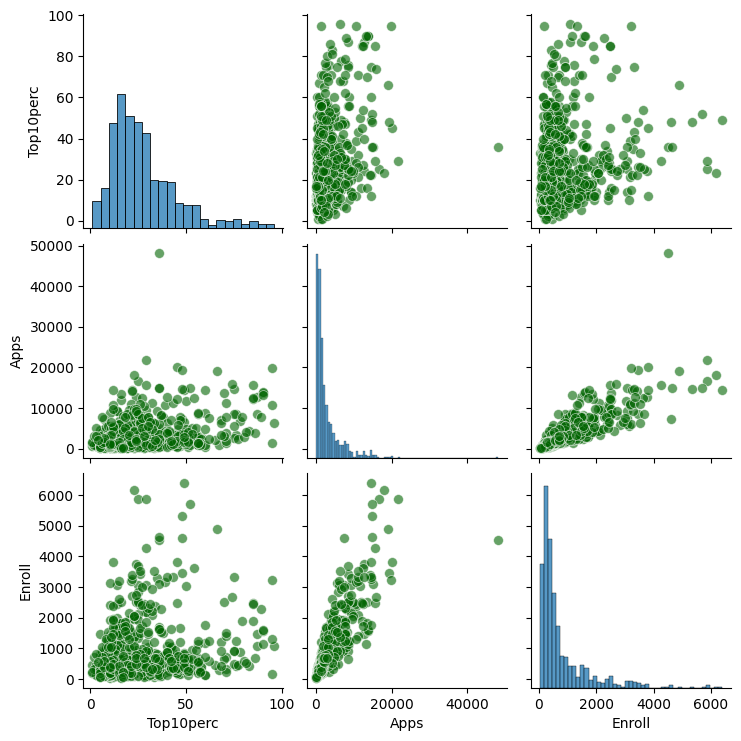

```python
sns.pairplot(data=college,vars=["Top10perc","Apps","Enroll"],plot_kws={'alpha': 0.6, 's': 50,"color":"darkgreen"})
```

**(e) Use the boxplot() method of college to produce side-by-side boxplots of Outstate versus Private.**

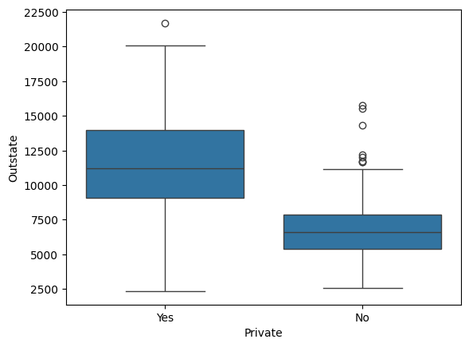

```python
sns.boxplot(data=college,y="Outstate",x="Private")
```

(f) Create a new qualitative variable, called Elite, by binning the Top10perc variable into two groups based on whether or not the  
proportion of students coming from the top 10% of their high school classes exceeds 50%.

```python
college["Elite"] = pd.cut(college["Top10perc"],bins=[0,50,100],labels=["No","Yes"])
college["Elite"]
```

```
College
Abilene Christian University       No
Adelphi University                 No
Adrian College                     No
Agnes Scott College               Yes
Alaska Pacific University          No
                                 ...
Worcester State College            No
Xavier University                  No
Xavier University of Louisiana     No
Yale University                   Yes
York College of Pennsylvania       No
Name: Elite, Length: 777, dtype: category
Categories (2, object): ['No' < 'Yes']
```

**Use the value_counts() method of college['Elite'] to see how many elite universities there are. Finally, use the boxplot() method again to produce side-by-side boxplots of Outstate versus Elite.**

```python
college["Elite"].value_counts()
```

```
Elite
No     699
Yes     78
Name: count, dtype: int64
```

There are **78** Elite universities.

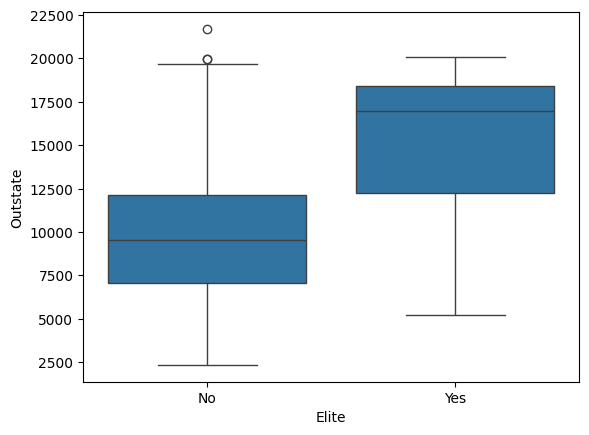

```python
sns.boxplot(data=college,x="Elite",y="Outstate")
```

(g) Use the plot.hist() method of college to produce some histograms with differing numbers of bins for a few of the quantitative variables. The command plt.subplots(2, 2) may be useful:  
it will divide the plot window into four regions so that four plots can be made simultaneously. By changing the arguments you can divide the screen up in other combinations.

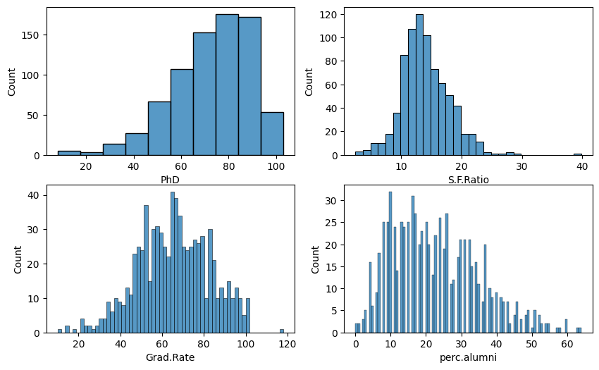

```python
fig, axes = plt.subplots(2, 2, figsize=(10, 6))
sns.histplot(x=college["PhD"],bins=10 ,ax=axes[0,0])
sns.histplot(x=college["S.F.Ratio"],bins=30,ax=axes[0,1])
sns.histplot(x=college["Grad.Rate"],bins=60,ax=axes[1,0])
sns.histplot(x=college["perc.alumni"],bins=100,ax=axes[1,1])
```

**(h) Continue exploring the data, and provide a brief summary of what you discover.**

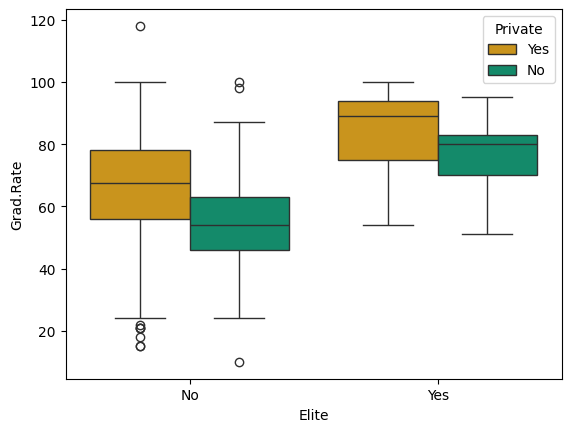

```python
sns.boxplot(data=college,x="Elite",y="Grad.Rate",hue="Private",palette=["#E69F00","#009E73"])
```

Colleges classified as elite, meaning they have more students from the top 10% of their high school class, tend to have higher graduation rates.  
In both elite and non-elite groups, private colleges generally show better graduation outcomes than public colleges.

10. This exercise involves the Boston housing data set.  
(a) To begin, load in the Boston data set, which is part of the ISLP library.

```python
from sklearn.datasets import fetch_openml
boston = fetch_openml(name="boston", version=1, as_frame=True)
df = boston.frame
```

**(b) How many rows are in this data set? How many columns? What do the rows and columns represent?**

```python
df.head()
```

|  | CRIM | ZN | INDUS | CHAS | NOX | RM | AGE | DIS | RAD | TAX | PTRATIO | B | LSTAT | MEDV |
| --- | --- | --- | --- | --- | --- | --- | --- | --- | --- | --- | --- | --- | --- | --- |
| 0 | 0.00632 | 18.0 | 2.31 | 0 | 0.538 | 6.575 | 65.2 | 4.0900 | 1 | 296.0 | 15.3 | 396.90 | 4.98 | 24.0 |
| 1 | 0.02731 | 0.0 | 7.07 | 0 | 0.469 | 6.421 | 78.9 | 4.9671 | 2 | 242.0 | 17.8 | 396.90 | 9.14 | 21.6 |
| 2 | 0.02729 | 0.0 | 7.07 | 0 | 0.469 | 7.185 | 61.1 | 4.9671 | 2 | 242.0 | 17.8 | 392.83 | 4.03 | 34.7 |
| 3 | 0.03237 | 0.0 | 2.18 | 0 | 0.458 | 6.998 | 45.8 | 6.0622 | 3 | 222.0 | 18.7 | 394.63 | 2.94 | 33.4 |
| 4 | 0.06905 | 0.0 | 2.18 | 0 | 0.458 | 7.147 | 54.2 | 6.0622 | 3 | 222.0 | 18.7 | 396.90 | 5.33 | 36.2 |

```python
print(f"Number of Rows = {df.shape[0]}")
print(f"Number of Column = {df.shape[1]}")
print(boston.DESCR)
```

```
Number of Rows = 506
Number of Column = 14
**Author**:
**Source**: Unknown - Date unknown
**Please cite**:

The Boston house-price data of Harrison, D. and Rubinfeld, D.L. 'Hedonic
prices and the demand for clean air', J. Environ. Economics & Management,
vol.5, 81-102, 1978.   Used in Belsley, Kuh & Welsch, 'Regression diagnostics
...', Wiley, 1980.   N.B. Various transformations are used in the table on
pages 244-261 of the latter.
Variables in order:
CRIM     per capita crime rate by town
ZN       proportion of residential land zoned for lots over 25,000 sq.ft.
INDUS    proportion of non-retail business acres per town
CHAS     Charles River dummy variable (= 1 if tract bounds river; 0 otherwise)
NOX      nitric oxides concentration (parts per 10 million)
RM       average number of rooms per dwelling
AGE      proportion of owner-occupied units built prior to 1940
DIS      weighted distances to five Boston employment centres
RAD      index of accessibility to radial highways
TAX      full-value property-tax rate per $10,000
PTRATIO  pupil-teacher ratio by town
B        1000(Bk - 0.63)^2 where Bk is the proportion of blacks by town
LSTAT    % lower status of the population
MEDV     Median value of owner-occupied homes in $1000's


Information about the dataset
CLASSTYPE: numeric
CLASSINDEX: last

Downloaded from openml.org.
```

Also each row represents a suburb of Boston ,so there are **506** suburbs in the dataset with **13** feature variable mentioned above and a target variavle (Median price of House per 1000s)

**(c) Make some pairwise scatterplots of the predictors (columns) in this data set. Describe your findings.**

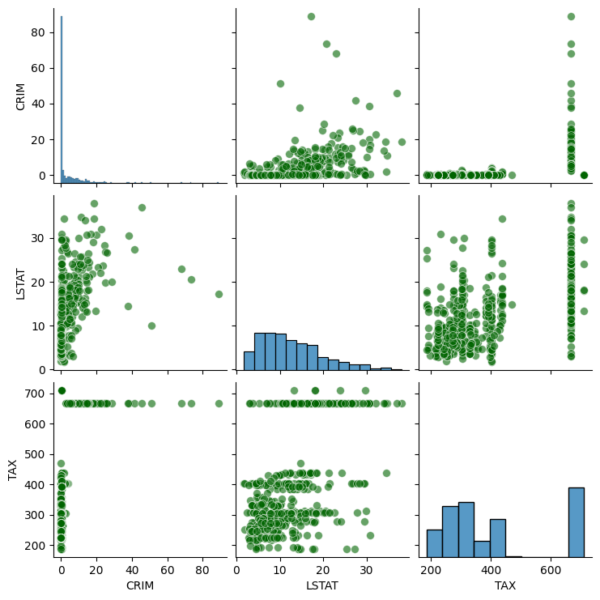

```python
sns.pairplot(data=df,vars=["CRIM","LSTAT","TAX"],plot_kws={'alpha': 0.6, 's': 50,"color":"darkgreen"})
```

**(d) Are any of the predictors associated with per capita crime rate? If so, explain the relationship.**

```python
df.corr(numeric_only=True)["CRIM"].sort_values()
```

```
MEDV      -0.388305
B         -0.385064
DIS       -0.379670
RM        -0.219247
ZN        -0.200469
PTRATIO    0.289946
AGE        0.352734
INDUS      0.406583
NOX        0.420972
LSTAT      0.455621
TAX        0.582764
CRIM       1.000000
Name: CRIM, dtype: float64
```

**(e) Do any of the suburbs of Boston appear to have particularly high crime rates? Tax rates? Pupil-teacher ratios? Comment on the range of each predictor.**

```python
df["CRIM"].describe()
```

```
count    506.000000
mean       3.613524
std        8.601545
min        0.006320
25%        0.082045
50%        0.256510
75%        3.677083
max       88.976200
Name: CRIM, dtype: float64
```

```python
df["TAX"].describe()
```

```
count    506.000000
mean     408.237154
std      168.537116
min      187.000000
25%      279.000000
50%      330.000000
75%      666.000000
max      711.000000
Name: TAX, dtype: float64
```

```python
df["PTRATIO"].describe()
```

```
count    506.000000
mean      18.455534
std        2.164946
min       12.600000
25%       17.400000
50%       19.050000
75%       20.200000
max       22.000000
Name: PTRATIO, dtype: float64
```

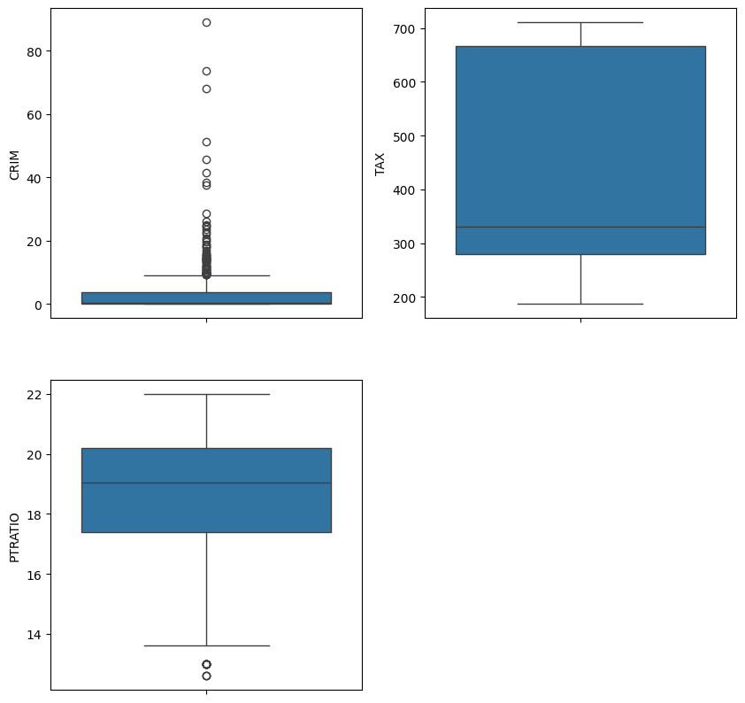

```python
fig,axes = plt.subplots(2,2,figsize=(10,10))

sns.boxplot(df,y="CRIM",ax=axes[0,0])

sns.boxplot(df,y="TAX",ax=axes[0,1])

sns.boxplot(df,y="PTRATIO",ax=axes[1,0])

axes[1, 1].set_visible(False)
```

**The CRIM (crime rate)** feature shows a significant number of high-value outliers, indicating that some suburbs experience much higher crime rates than others.  
**In contrast, the PTRATIO (pupil-to-teacher ratio)** feature has only a few mild outliers, suggesting relatively consistent values across most areas.

**(f) How many of the suburbs in this data set bound the Charles river?**

```python
df["CHAS"].value_counts()
```

```
CHAS
0    471
1     35
Name: count, dtype: int64
```

**35** suburbs are set bound the Charles river.

**(g) What is the median pupil-teacher ratio among the towns in this data set?**

```python
df["PTRATIO"].median()
```

```
np.float64(19.05)
```

The median pupil-teacher ratio is **19.05**

(h) Which suburb of Boston has lowest median value of owner-occupied homes? What are the values of the other predictors  
for that suburb, and how do those values compare to the overall ranges for those predictors? Comment on your findings.

```python
df[df["MEDV"]== df["MEDV"].min()]
```

|  | CRIM | ZN | INDUS | CHAS | NOX | RM | AGE | DIS | RAD | TAX | PTRATIO | B | LSTAT | MEDV |
| --- | --- | --- | --- | --- | --- | --- | --- | --- | --- | --- | --- | --- | --- | --- |
| 398 | 38.3518 | 0.0 | 18.1 | 0 | 0.693 | 5.453 | 100.0 | 1.4896 | 24 | 666.0 | 20.2 | 396.90 | 30.59 | 5.0 |
| 405 | 67.9208 | 0.0 | 18.1 | 0 | 0.693 | 5.683 | 100.0 | 1.4254 | 24 | 666.0 | 20.2 | 384.97 | 22.98 | 5.0 |

```python
df.describe()
```

|  | CRIM | ZN | INDUS | NOX | RM | AGE | DIS | TAX | PTRATIO | B | LSTAT | MEDV |
| --- | --- | --- | --- | --- | --- | --- | --- | --- | --- | --- | --- | --- |
| count | 506.000000 | 506.000000 | 506.000000 | 506.000000 | 506.000000 | 506.000000 | 506.000000 | 506.000000 | 506.000000 | 506.000000 | 506.000000 | 506.000000 |
| mean | 3.613524 | 11.363636 | 11.136779 | 0.554695 | 6.284634 | 68.574901 | 3.795043 | 408.237154 | 18.455534 | 356.674032 | 12.653063 | 22.532806 |
| std | 8.601545 | 23.322453 | 6.860353 | 0.115878 | 0.702617 | 28.148861 | 2.105710 | 168.537116 | 2.164946 | 91.294864 | 7.141062 | 9.197104 |
| min | 0.006320 | 0.000000 | 0.460000 | 0.385000 | 3.561000 | 2.900000 | 1.129600 | 187.000000 | 12.600000 | 0.320000 | 1.730000 | 5.000000 |
| 25% | 0.082045 | 0.000000 | 5.190000 | 0.449000 | 5.885500 | 45.025000 | 2.100175 | 279.000000 | 17.400000 | 375.377500 | 6.950000 | 17.025000 |
| 50% | 0.256510 | 0.000000 | 9.690000 | 0.538000 | 6.208500 | 77.500000 | 3.207450 | 330.000000 | 19.050000 | 391.440000 | 11.360000 | 21.200000 |
| 75% | 3.677083 | 12.500000 | 18.100000 | 0.624000 | 6.623500 | 94.075000 | 5.188425 | 666.000000 | 20.200000 | 396.225000 | 16.955000 | 25.000000 |
| max | 88.976200 | 100.000000 | 27.740000 | 0.871000 | 8.780000 | 100.000000 | 12.126500 | 711.000000 | 22.000000 | 396.900000 | 37.970000 | 50.000000 |

(i) In this data set, how many of the suburbs average more than seven rooms per dwelling? More than eight rooms per dwelling?  
Comment on the suburbs that average more than eight rooms per dwelling.

```python
more_than_7 = df[df["RM"] > 7]
len(more_than_7)
```

```
64
```

**64** suburbs has more than 7 rooms per dwelling.

```python
more_than_8 = df[df["RM"]>8]
len(more_than_8)
```

```
13
```

**13** suburbs has more than 8 rooms per dwelling.

```python
more_than_8.describe()
```

|  | CRIM | ZN | INDUS | NOX | RM | AGE | DIS | TAX | PTRATIO | B | LSTAT | MEDV |
| --- | --- | --- | --- | --- | --- | --- | --- | --- | --- | --- | --- | --- |
| count | 13.000000 | 13.000000 | 13.000000 | 13.000000 | 13.000000 | 13.000000 | 13.000000 | 13.000000 | 13.000000 | 13.000000 | 13.000000 | 13.000000 |
| mean | 0.718795 | 13.615385 | 7.078462 | 0.539238 | 8.348538 | 71.538462 | 3.430192 | 325.076923 | 16.361538 | 385.210769 | 4.310000 | 44.200000 |
| std | 0.901640 | 26.298094 | 5.392767 | 0.092352 | 0.251261 | 24.608723 | 1.883955 | 110.971063 | 2.410580 | 10.529359 | 1.373566 | 8.092383 |
| min | 0.020090 | 0.000000 | 2.680000 | 0.416100 | 8.034000 | 8.400000 | 1.801000 | 224.000000 | 13.000000 | 354.550000 | 2.470000 | 21.900000 |
| 25% | 0.331470 | 0.000000 | 3.970000 | 0.504000 | 8.247000 | 70.400000 | 2.288500 | 264.000000 | 14.700000 | 384.540000 | 3.320000 | 41.700000 |
| 50% | 0.520140 | 0.000000 | 6.200000 | 0.507000 | 8.297000 | 78.300000 | 2.894400 | 307.000000 | 17.400000 | 386.860000 | 4.140000 | 48.300000 |
| 75% | 0.578340 | 20.000000 | 6.200000 | 0.605000 | 8.398000 | 86.500000 | 3.651900 | 307.000000 | 17.400000 | 389.700000 | 5.120000 | 50.000000 |
| max | 3.474280 | 95.000000 | 19.580000 | 0.718000 | 8.780000 | 93.900000 | 8.906700 | 666.000000 | 20.200000 | 396.900000 | 7.440000 | 50.000000 |

```python
df.describe()
```

|  | CRIM | ZN | INDUS | NOX | RM | AGE | DIS | TAX | PTRATIO | B | LSTAT | MEDV |
| --- | --- | --- | --- | --- | --- | --- | --- | --- | --- | --- | --- | --- |
| count | 506.000000 | 506.000000 | 506.000000 | 506.000000 | 506.000000 | 506.000000 | 506.000000 | 506.000000 | 506.000000 | 506.000000 | 506.000000 | 506.000000 |
| mean | 3.613524 | 11.363636 | 11.136779 | 0.554695 | 6.284634 | 68.574901 | 3.795043 | 408.237154 | 18.455534 | 356.674032 | 12.653063 | 22.532806 |
| std | 8.601545 | 23.322453 | 6.860353 | 0.115878 | 0.702617 | 28.148861 | 2.105710 | 168.537116 | 2.164946 | 91.294864 | 7.141062 | 9.197104 |
| min | 0.006320 | 0.000000 | 0.460000 | 0.385000 | 3.561000 | 2.900000 | 1.129600 | 187.000000 | 12.600000 | 0.320000 | 1.730000 | 5.000000 |
| 25% | 0.082045 | 0.000000 | 5.190000 | 0.449000 | 5.885500 | 45.025000 | 2.100175 | 279.000000 | 17.400000 | 375.377500 | 6.950000 | 17.025000 |
| 50% | 0.256510 | 0.000000 | 9.690000 | 0.538000 | 6.208500 | 77.500000 | 3.207450 | 330.000000 | 19.050000 | 391.440000 | 11.360000 | 21.200000 |
| 75% | 3.677083 | 12.500000 | 18.100000 | 0.624000 | 6.623500 | 94.075000 | 5.188425 | 666.000000 | 20.200000 | 396.225000 | 16.955000 | 25.000000 |
| max | 88.976200 | 100.000000 | 27.740000 | 0.871000 | 8.780000 | 100.000000 | 12.126500 | 711.000000 | 22.000000 | 396.900000 | 37.970000 | 50.000000 |

we can conclude that suburbs having more than 8 rooms per dwelling have very less crime rater (CRIM) values.  
Also, these have less value of LSTAT, and theit target value, price is signifanctly larger than the overall mean price of the whole dataset